# DSCI101_HW2

Lily Kraus

2023-01-31

1. Using the Teams data frame in Lahman package

   ```r
   library(Lahman)
   library(ggplot2)
   library(dplyr)
   data("Teams")
   View(Teams)
   ```

a. Create a data frame that is a subset of the Teams data frame that contains only the years from 2000 through 2009 and the variables yearID, W, and L.

```r
Teams_subset <- Teams %>% select(yearID,W,L) %>% filter(yearID >= 2000 & yearID <= 2009)
```

b. How many years did the Chicago Cubs (teamID is “CHN”) hit at least 200 HRs in a season and what was the median number of wins in those seasons.

There are 7 years in which the Chicago Cubs hit at least 200 HR’s in a season. The median number of wins in those seasons is 84 wins.

```r
HR200years <- Teams %>% filter(teamID == "CHN" & HR >= 200) %>% nrow()

HR200year_median <- Teams %>% filter(teamID == "CHN" & HR >= 200) %>% summarise(median_wins = median(W))
```

c. Make a line plot of total home runs per season and stratify by league. (Remove observations where league is missing.) Comment on anything interesting that you observe.

One interesting thing that I observed is that initially there were more leagues than just the American League and the National League. I also wasn’t aware that there was such a large increase in the number of home runs starting around 1920.

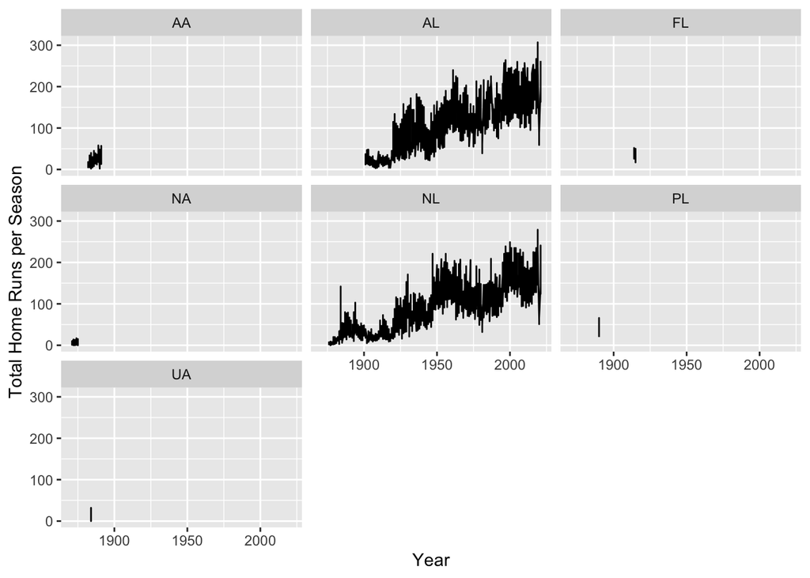

```r
leagues <- Teams %>% group_by(lgID, na.rm = TRUE)

ggplot(leagues, aes(x = yearID, y = HR)) +
  geom_line() + xlab("Year") + ylab("Total Home Runs per Season") + facet_wrap(~lgID)
```

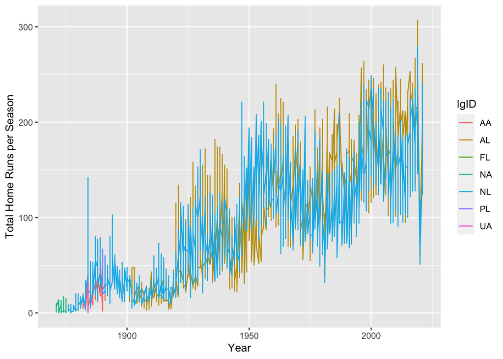

```r
ggplot(leagues, aes(x = yearID, y = HR, color=lgID)) +
  geom_line() + xlab("Year") + ylab("Total Home Runs per Season")
```

d. Create an indicator variable called “winning record” which is defined as TRUE if the number of wins is greater than the number of losses and FALSE otherwise. Plot a scatter plot Runs (R) vs Runs against (RA) with the color of each point showing whether that team had a winning record or not.

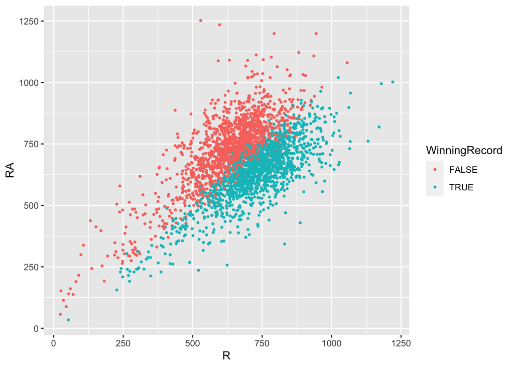

```r
W_record <- Teams %>% mutate(WinningRecord = W > L)

ggplot(data = W_record, aes(x = R, y = RA)) +
  geom_point(aes(color = WinningRecord),size = 0.7)
```

e. Using ggplot2, create a scatterplot of strikeouts (SO) vs walks (BB).

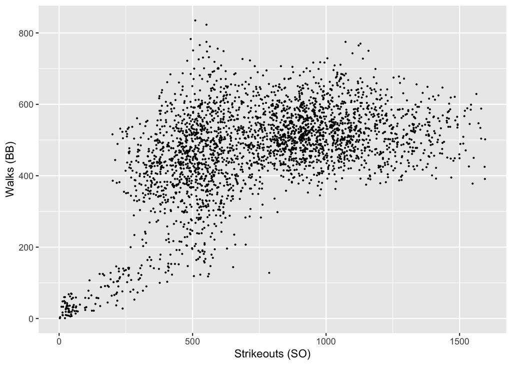

```r
ggplot(data = Teams, aes(x = SO, y = BB)) + geom_point(size = 0.3) + xlab("Strikeouts (SO)") + ylab("Walks (BB)")
```

f. Create a categorical variable with 4 levels: before 1900, 1900 - 1949, 1950-1999, 2000 or later. (Hint: There is a function called ‘cut’ that will help you here.) Use this as the color of the point in the scatterplot of strikeouts vs walks that you created in the previous problem.

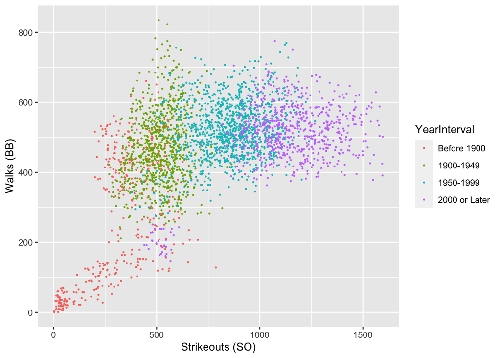

```r
Years <- min(Teams$yearID):max(Teams$yearID)
first_year <- min(Teams$yearID)
last_year <- max(Teams$yearID)

Teams$YearInterval <- cut(Teams$yearID,
                  breaks = c(0,1899,1950,1999,last_year),
                  labels = c("Before 1900","1900-1949","1950-1999","2000 or Later"))

ggplot(data = Teams, aes(x = SO, y = BB,color=YearInterval)) + geom_point(size=0.3) + xlab("Strikeouts (SO)") + ylab("Walks (BB)")
```

2. Use the nycflights13 package and the flights data frame to answer the following questions:

```r
library(nycflights13)
data("flights")
head(flights)
```

```
## # A tibble: 6 × 19
##    year month   day dep_time sched_dep…¹ dep_d…² arr_t…³ sched…⁴ arr_d…⁵ carrier
##   <int> <int> <int>    <int>       <int>   <dbl>   <int>   <int>   <dbl> <chr>
## 1  2013     1     1      517         515       2     830     819      11 UA
## 2  2013     1     1      533         529       4     850     830      20 UA
## 3  2013     1     1      542         540       2     923     850      33 AA
## 4  2013     1     1      544         545      -1    1004    1022     -18 B6
## 5  2013     1     1      554         600      -6     812     837     -25 DL
## 6  2013     1     1      554         558      -4     740     728      12 UA
## # … with 9 more variables: flight <int>, tailnum <chr>, origin <chr>,
## #   dest <chr>, air_time <dbl>, distance <dbl>, hour <dbl>, minute <dbl>,
## #   time_hour <dttm>, and abbreviated variable names ¹sched_dep_time,
## #   ²dep_delay, ³arr_time, ⁴sched_arr_time, ⁵arr_delay
```

a. What month had the highest proportion of cancelled flights? What month had the lowest? Interpret any seasonal patterns.

February had the highest proportion of cancelled flights and November had the lowest. I was expecting there to be a more distinct seasonal pattern. It makes sense that February has a high proportion of cancelled flights, considering the weather. However, June and July also have high proportions of cancelled flights

```r
month_flights <- flights %>% group_by(month) %>% mutate(cancelled = is.na(air_time)) %>% summarise(CancelledFlights = sum(cancelled == TRUE), TotalFlights = n()) %>% mutate(PropCancelled = CancelledFlights/TotalFlights) %>% arrange(-PropCancelled)
```

b. Create a histogram of the departure delays times (dep delay) for all flights that had a delay time greater than 0.

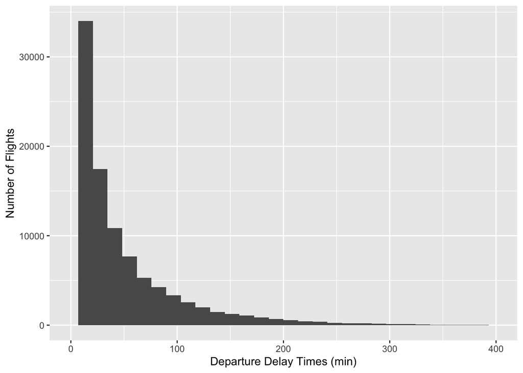

```r
#filter to get flights delay time > 0
DelayFlights <- flights %>% filter(dep_delay > 0) %>% mutate(MonthName = month.name[month])

#add bins parameter to make it look better
ggplot(aes(x = dep_delay), data = DelayFlights) + geom_histogram() + xlab("Departure Delay Times (min)") + ylab("Number of Flights") + xlim(0,400)
```

c. Repeat the same histogram, but now facet by month.

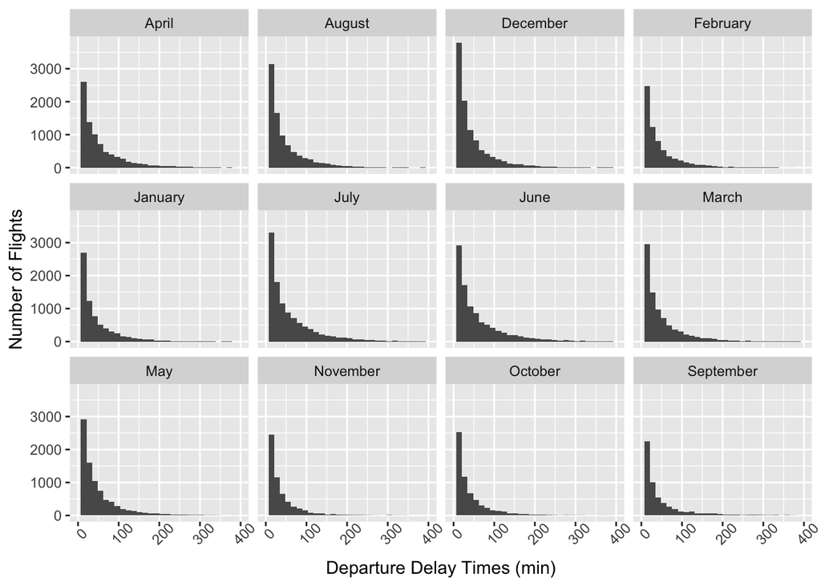

```r
ggplot(aes(x = dep_delay), data = DelayFlights) + geom_histogram() + xlab("Departure Delay Times (min)") + ylab("Number of Flights") + facet_wrap(~MonthName) + xlim(0,400) + theme(axis.text.x = element_text(angle = 45))
```

d. Create side-by-side boxplots of delay times for flights with delays 60 minutes or greater for the top 5 airlines (in terms of number of flights).

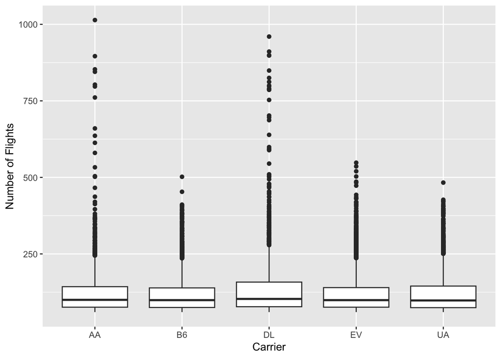

```r
#Get top 5 airlines with highest number of flights

#Finding the top 5 airlines in terms of number of flights
top_airlines <- flights %>% group_by(carrier) %>% summarise(TotalFlights = sum(n())) %>% arrange(-TotalFlights) %>% head(5)%>% select(carrier)

#Filtering flights with delays greater than or equal to 60 min and only by the carriers that are in the top 5
top_airlines_delay <- flights %>% mutate(Top5 = carrier %in% top_airlines$carrier) %>% filter(dep_delay >= 60 & Top5 == TRUE)


ggplot(aes(y=dep_delay,x=carrier), data=top_airlines_delay) + geom_boxplot() + ylab("Number of Flights") + xlab("Carrier")
```